# Aurel Sheremetaj Lindjet

Aurel Sheremetaj

21 December 2025

# Hyrje

Qëllimi i këtij studimi është analiza e tendencave dhe lidhjeve mes tre treguesve kryesorë për ekonominë dhe zhvillimin shoqëror të Shqipërisë gjatë periudhës 2011–2025, përmes të dhënave tremujore. Të dhënat përfshijnë: (1) numrin e lindjeve në Shqipëri nga tremujori i parë i vitit 2011 deri në tremujorin e dytë të vitit 2025, (2) indeksin tremujor të çmimeve të importit të Shqipërisë nga tremujori i parë i vitit 2012 deri në tremujorin e dytë të vitit 2025, dhe (3) bilancin tremujor të energjisë elektrike për eksportet bruto të Shqipërisë për të njëjtën periudhë. Këto seri kohore përfaqësojnë tre dimensione të ndryshme të zhvillimit kombëtar – demografik, ekonomik dhe energjetik – të cilat janë të ndërlidhura në mënyrë sistematike dhe ndikojnë ndërsjelltë në stabilitetin dhe performancën e vendit.Në datasetin e parë, treguesi i lindjeve pasqyron ecurinë demografike të vendit, si dhe ndryshimet strukturore që lidhen me faktorë ekonomikë, emigracionin dhe politikat sociale. Këto të dhëna do të analizohen për të identifikuar trendet afatgjata, stinorësinë dhe mundësitë për parashikim të numrit të lindjeve në të ardhmen. Në datasetin e dytë, analiza fokusohet në indeksin e çmimeve të importit, i cili është tregues i rëndësishëm i dinamikës së tregtisë së jashtme dhe i presioneve të inflacionit që ndikojnë në ekonominë shqiptare. Duke analizuar këtë seri kohore, synohet të vlerësohen ndryshimet ciklike dhe ndikimet e faktorëve globalë në çmimet e importit për vendin. Dataseti i tretë përfshin bilancin tremujor të energjisë elektrike për eksportet bruto, një tregues kyç për kapacitetin energjetik të Shqipërisë, i cili ndikohet drejtpërdrejt nga kushtet klimatike, prodhimi hidroenergjetik dhe kërkesa e tregut rajonal. Ky tregues ndihmon të kuptohet më mirë roli i sektorit energjetik në ekonominë shqiptare dhe kontributi i tij në balancën tregtare.Secili prej tre treguesve do të analizohet përmes metodave statistikore të serive kohore në R Studio, duke përfshirë vizualizimin, dekompozimin në komponentët trend, sezonë dhe rastësorë, si dhe ndërtimin e modeleve për parashikim .Parashikimi i saktë i këtyre treguesve ndihmon në formulimin e politikave afatgjata për zhvillim të qëndrueshëm, menaxhim të burimeve natyrore dhe planifikim të tregut të punës. Përmes këtij punimi synohet të krijohet një kuptim gjithëpërfshirës mbi mënyrën se si ndryshimet në faktorët demografikë, ekonominë e jashtme dhe energjinë ndikojnë në performancën makroekonomike të Shqipërisë dhe si mund të përdoren metodat e statistikës moderne për të parashikuar ecurinë e tyre në të ardhmen.

# Paraqitja grafike

```r
library(readxl)

data <- read_excel("C:\\Users\\35569\\OneDrive\\Documents\\Lindjet 3 mujor.xlsx")
head(data)
```

| Koha | Gjithsej |
| --- | --- |
| 2011-1 | 7425 |
| 2011-2 | 8238 |
| 2011-3 | 9807 |
| 2011-4 | 8815 |
| 2012-1 | 8082 |
| 2012-2 | 8471 |

```r
library(ggplot2)
library(forecast)
library(dplyr)
library(tidyr)
```

```r
library(dplyr)
library(tidyr)

data <- data %>%
  separate(Koha, into = c("Viti", "Tremujori"), sep = "-", convert = TRUE)

head(data)
```

| Viti | Tremujori | Gjithsej |
| --- | --- | --- |
| 2011 | 1 | 7425 |
| 2011 | 2 | 8238 |
| 2011 | 3 | 9807 |
| 2011 | 4 | 8815 |
| 2012 | 1 | 8082 |
| 2012 | 2 | 8471 |

```r
ts_births <- ts(
  data$Gjithsej,
  start = c(min(data$Viti), min(data$Tremujori)),
  frequency = 4
)

ts_births
```

```
##       Qtr1  Qtr2  Qtr3  Qtr4
## 2011  7425  8238  9807  8815
## 2012  8082  8471 10257  8663
## 2013  7868  8382 10208  9292
## 2014  8002  8741 10329  8688
## 2015  7646  7991  8715  8363
## 2016  7163  7365  9086  8119
## 2017  6916  7483  8539  7931
## 2018  6657  6745  8213  7319
## 2019  6257  6655  7739  7910
## 2020  6351  6706  8007  7011
## 2021  6301  6319  7680  6911
## 2022  6214  5577  6555  6342
## 2023  5424  5452  6515  6226
## 2024  5428  5380  6483  6019
## 2025  4662  4982
```

### Grafikë

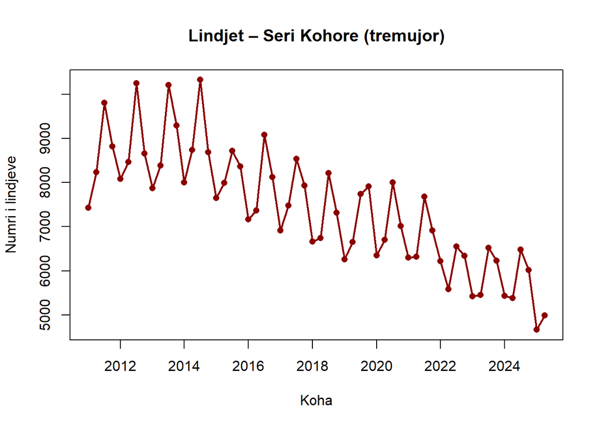

```r
plot(ts_births,
     type = "o",
     col = "darkred",
     pch = 16,
     lwd = 2,
     main = "Lindjet – Seri Kohore (tremujor)",
     ylab = "Numri i lindjeve",
     xlab = "Koha")
```

### sezonalitet

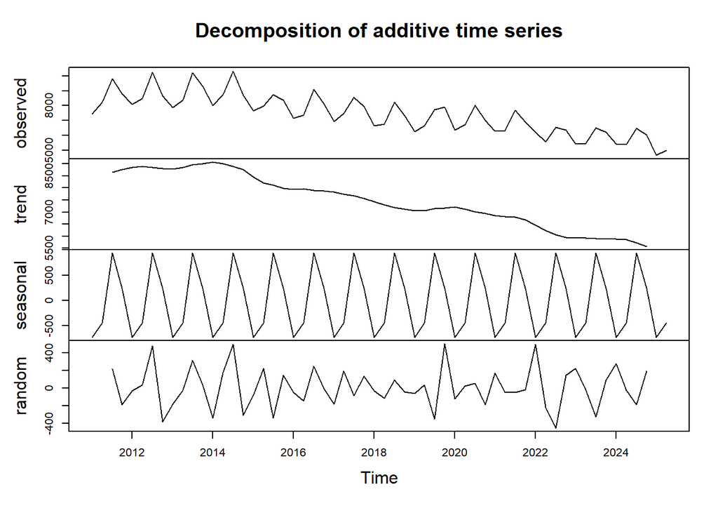

```r
 #sezonaliteti trendi
decomp <- decompose(ts_births)
plot(decomp)
```

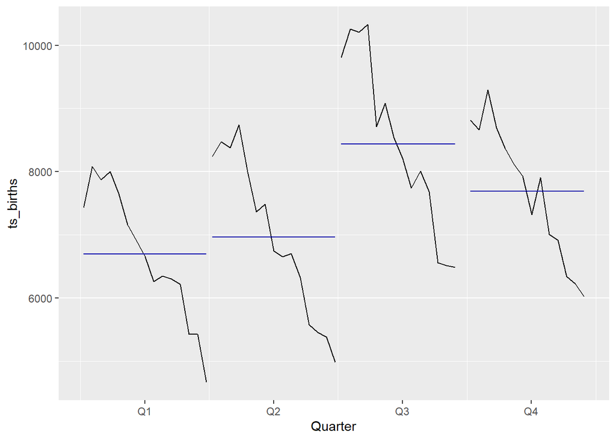

```r
  ggsubseriesplot(ts_births)
```

### Grafiku sezonal

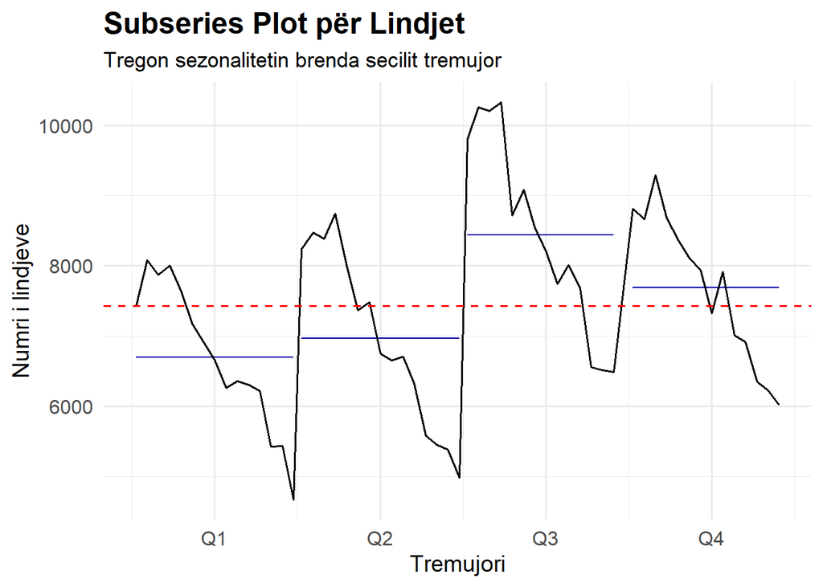

```r
library(forecast)
library(ggplot2)

ggsubseriesplot(ts_births, color = "black") +
  geom_line(aes(group = 1), color = "black", linewidth = 0.7) +
  geom_hline(aes(yintercept = mean(ts_births)),
             color = "red", linetype = "dashed", linewidth = 0.7) +
  theme_minimal(base_size = 14) +
  labs(
    title = "Subseries Plot për Lindjet",
    subtitle = "Tregon sezonalitetin brenda secilit tremujor",
    x = "Tremujori",
    y = "Numri i lindjeve"
  ) +
  theme(
    plot.title = element_text(face = "bold", size = 18),
    plot.subtitle = element_text(size = 13),
    strip.text = element_text(size = 14, face = "bold"),
    axis.text = element_text(size = 12),
    axis.title = element_text(size = 14)
  )
```

### Kontrolli i stacionaritetit

```r
library(tseries)
adf.test(ts_births)
```

```
##
##  Augmented Dickey-Fuller Test
##
## data:  ts_births
## Dickey-Fuller = -3.2138, Lag order = 3, p-value = 0.09401
## alternative hypothesis: stationary
```

Duke bërë kontrollin nëse seria është stacionare ose jo del që vlera p=0.09401 ku duket që seria jonë është jostacionare

# Sheshimi ekspoencial

Në këtë pjesë do të shikojmë zbatimin e sheshimit eksponencial per serinë tonë nepermjet 3 niveleve te sheshimit eksponencal të njëfishtë(SES) pa trend, pa sezonalitet, të dyfishtë (Holt) me trend, pa sezonalitet, të trefishtë (Holt–Winters) me trend dhe sezonalitet

## Train/testing

Si fillim do te shikojmë pjesen e trajnimit dhe testimit për serinë tonë

```r
h_test <- 8   # 8 tremujorë = 2 vite të fundit
n <- length(ts_births)
cut_point <- time(ts_births)[n - h_test]
ts_train <- window(ts_births, end = cut_point)
ts_test <- window(ts_births, start = cut_point + deltat(ts_births))
ts_train
```

```
##       Qtr1  Qtr2  Qtr3  Qtr4
## 2011  7425  8238  9807  8815
## 2012  8082  8471 10257  8663
## 2013  7868  8382 10208  9292
## 2014  8002  8741 10329  8688
## 2015  7646  7991  8715  8363
## 2016  7163  7365  9086  8119
## 2017  6916  7483  8539  7931
## 2018  6657  6745  8213  7319
## 2019  6257  6655  7739  7910
## 2020  6351  6706  8007  7011
## 2021  6301  6319  7680  6911
## 2022  6214  5577  6555  6342
## 2023  5424  5452
```

```r
ts_test
```

```
##      Qtr1 Qtr2 Qtr3 Qtr4
## 2023           6515 6226
## 2024 5428 5380 6483 6019
## 2025 4662 4982
```

## Sheshimi eksponencial i njëfishtë

```r
fit_ses <- ses(ts_train,
               h = h_test,
               initial = "optimal")

fit_ses
```

```
##         Point Forecast    Lo 80    Hi 80    Lo 95    Hi 95
## 2023 Q3       6036.354 4899.818 7172.890 4298.172 7774.536
## 2023 Q4       6036.354 4866.865 7205.843 4247.774 7824.933
## 2024 Q1       6036.354 4834.815 7237.893 4198.758 7873.950
## 2024 Q2       6036.354 4803.598 7269.110 4151.016 7921.692
## 2024 Q3       6036.354 4773.152 7299.556 4104.454 7968.254
## 2024 Q4       6036.354 4743.423 7329.285 4058.987 8013.721
## 2025 Q1       6036.354 4714.363 7358.345 4014.543 8058.165
## 2025 Q2       6036.354 4685.927 7386.781 3971.055 8101.653
```

Për serinë e lindjeve u aplikua modeli i sheshimit eksponencial të njëfishtë (SES).Duke përdorur të dhënat e trajnimit, SES vlerësoi parametrin optimal α dhe prodhoi parashikime konstante për 8 tremujorët e testimit. Të gjitha parashikimet janë rreth vlerës 6036, gjë që tregon se modeli SES nuk arrin të kapë trendin zbritës që vërehet në seri.

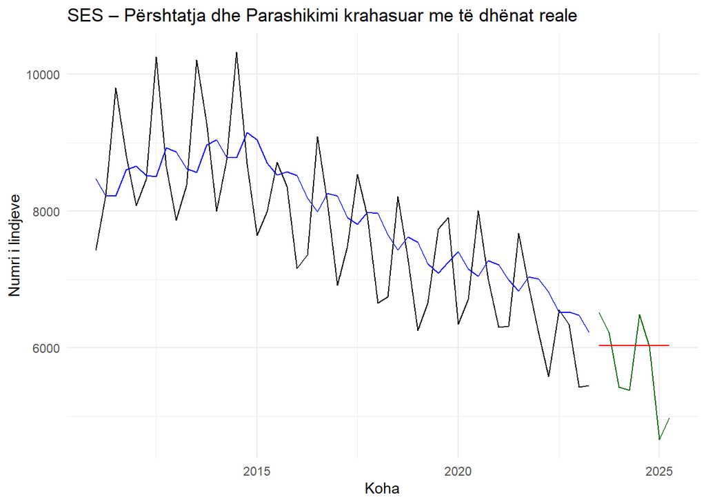

```r
autoplot(ts_train, series = "Train", color = "black") +
  autolayer(fitted(fit_ses), series = "Përshtatja (Fitted)", color = "blue") +
  autolayer(ts_test, series = "Reale (Test)", color = "darkgreen") +
  autolayer(fit_ses$mean, series = "Parashikimi (SES)", color = "red") +
  labs(title = "SES – Përshtatja dhe Parashikimi krahasuar me të dhënat reale",
       x = "Koha",
       y = "Numri i lindjeve") +
  guides(colour = guide_legend(title = "Seria")) +
  theme_minimal()
```

```r
# Tabela e saktësisë
acc_ses <- accuracy(fit_ses, ts_test)
acc_ses
```

```
##                     ME     RMSE      MAE       MPE      MAPE     MASE
## Training set -200.9764 868.9258 722.3179 -3.906778  9.630332 1.780252
## Test set     -324.4790 730.2626 603.2135 -7.132093 11.452682 1.486703
##                    ACF1 Theil's U
## Training set 0.07199133        NA
## Test set     0.22953432  1.056315
```

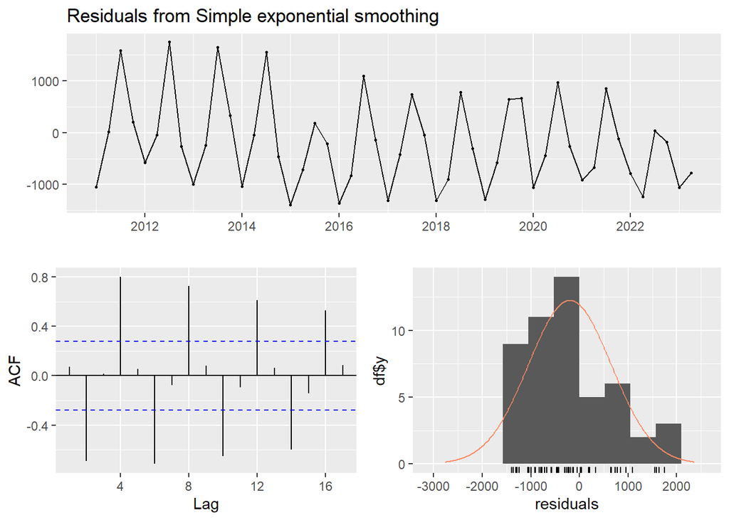

```
##
##  Ljung-Box test
##
## data:  Residuals from Simple exponential smoothing
## Q* = 125.39, df = 8, p-value < 2.2e-16
##
## Model df: 0.   Total lags used: 8
```

```r
# Kontrolli i mbetjeve
checkresiduals(fit_ses)
```

Grafiku tregon se modeli SES nuk arrin të përshtatet mirë me serinë e lindjeve. Edhe pse vlerat e përshtatura (qe ne kete rast eshte vija blu) e ndjekin serinë në mënyrë të përgjithshme, ato nuk pasqyrojnë dot sezonalitetin tremujor dhe trendin në rënie. Analiza e mbetjeve tregon se modeli SES nuk përshtatet mirë me serinë e lindjeve. Mbetjet paraqesin autokorelacion të fortë dhe nuk sillen si zhurme e bardhe . Grafiku i ACF dhe histogrami tregojnë se modeli nuk arrin të kapë trendin dhe sezonalitetin e serisë. Prandaj SES nuk është model i përshtatshëm për parashikime në këtë rast.

## Sheshimi eksponenial i dyfishte

```r
fit_holt <- holt(ts_train, h = h_test)
fit_holt
```

```
##         Point Forecast    Lo 80    Hi 80    Lo 95    Hi 95
## 2023 Q3       6073.549 4978.859 7168.239 4399.365 7747.733
## 2023 Q4       6017.878 4918.617 7117.138 4336.703 7699.052
## 2024 Q1       5962.206 4858.384 7066.029 4274.056 7650.357
## 2024 Q2       5906.535 4798.160 7014.910 4211.422 7601.648
## 2024 Q3       5850.863 4737.945 6963.782 4148.801 7552.926
## 2024 Q4       5795.192 4677.738 6912.646 4086.193 7504.191
## 2025 Q1       5739.521 4617.540 6861.502 4023.599 7455.443
## 2025 Q2       5683.849 4557.350 6810.349 3961.017 7406.682
```

Tabela paraqet parashikimet e modelit Holt për 8 tremujorët e ardhshëm. Ky model merr parasysh trendin në rënie të serisë, ndaj vlerat e parashikuara zbresin gradualisht nga 6073 lindje në 2023 Q3 deri në rreth 5683 lindje në 2025 Q2.

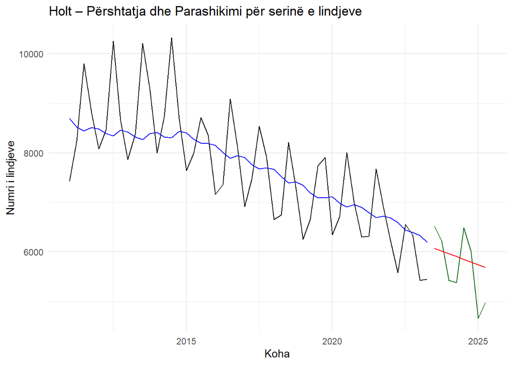

```r
autoplot(ts_train, series = "Train", color = "black") +
  autolayer(fitted(fit_holt), series = "Përshtatja (Fitted)", color = "blue") +
  autolayer(ts_test, series = "Reale (Test)", color = "darkgreen") +
  autolayer(fit_holt$mean, series = "Parashikimi (Holt)", color = "red") +
  labs(title = "Holt – Përshtatja dhe Parashikimi për serinë e lindjeve",
       x = "Koha",
       y = "Numri i lindjeve") +
  guides(colour = guide_legend(title = "Seria")) +
  theme_minimal()
```

```r
# Saktësia për modelin Holt
acc_holt <- accuracy(fit_holt, ts_test)
acc_holt
```

```
##                      ME     RMSE      MAE        MPE      MAPE     MASE
## Training set   32.82308 819.3115 660.8020 -0.8580183  8.570681 1.628638
## Test set     -166.82416 602.5093 543.2036 -4.1551709 10.052108 1.338800
##                   ACF1 Theil's U
## Training set 0.1236690        NA
## Test set     0.1412184 0.8497919
```

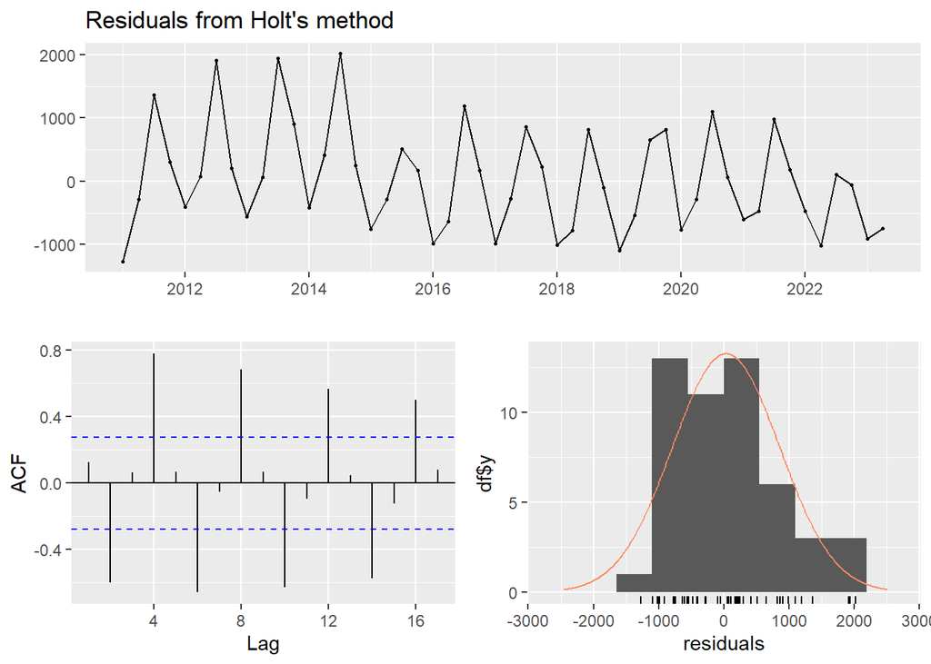

```
##
##  Ljung-Box test
##
## data:  Residuals from Holt's method
## Q* = 109.29, df = 8, p-value < 2.2e-16
##
## Model df: 0.   Total lags used: 8
```

```r
# Kontrolli i mbetjeve të modelit Holt
checkresiduals(fit_holt)
```

Holt përshtatet mirë me trendin zbritës të lindjeve, por nuk kap sezonalitetin. Në testim, parashikimet janë afër vlerave reale, megjithëse më të lëmuara. Modeli projeksionon një vazhdimësi të rënies së lindjeve në periudhën e ardhshme. Rezultatet e saktësisë tregojnë se modeli Holt performon dukshëm më mirë se modeli SES. Gabimet RMSE dhe MAE janë më të ulëta. Holt kap trendin e serisë dhe jep parashikime më të sakta për të dhënat e testit.

## Sheshimi eksponencial i trefishte

```r
# Modeli Holt–Winters me sezonalitet ADDITIV
fit_hw_add <- hw(ts_train, h = h_test, seasonal = "additive")
fit_hw_add
```

```
##         Point Forecast    Lo 80    Hi 80    Lo 95    Hi 95
## 2023 Q3       6950.049 6453.564 7446.535 6190.740 7709.359
## 2023 Q4       6112.699 5576.780 6648.619 5293.081 6932.317
## 2024 Q1       5010.646 4437.970 5583.323 4134.813 5886.480
## 2024 Q2       5264.661 4657.417 5871.905 4335.962 6193.360
## 2024 Q3       6716.802 6076.811 7356.793 5738.020 7695.584
## 2024 Q4       5879.452 5208.297 6550.607 4853.008 6905.896
## 2025 Q1       4777.399 4076.437 5478.361 3705.370 5849.428
## 2025 Q2       5031.414 4301.836 5760.992 3915.621 6147.207
```

Modeli Holt–Winters me sezonalitet additiv prodhon parashikime që pasqyrojnë si trendin zbritës, ashtu edhe ndryshimet sezonale të lindjeve.

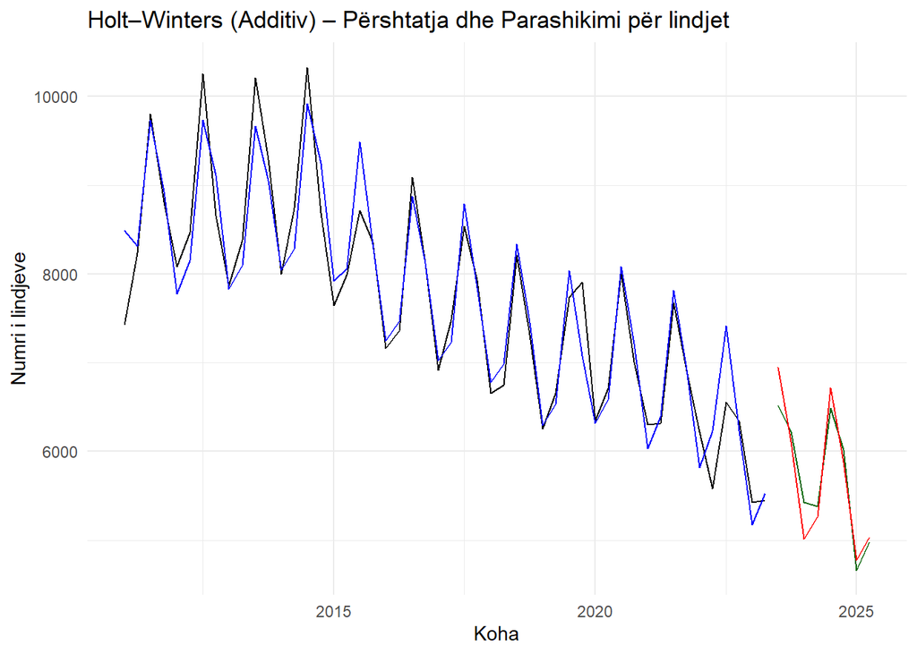

```r
autoplot(ts_train, series = "Train", color = "black") +
  autolayer(fitted(fit_hw_add), series = "Përshtatja (Fitted)", color = "blue") +
  autolayer(ts_test, series = "Reale (Test)", color = "darkgreen") +
  autolayer(fit_hw_add$mean, series = "Parashikimi (HW Additiv)", color = "red") +
  labs(title = "Holt–Winters (Additiv) – Përshtatja dhe Parashikimi për lindjet",
       x = "Koha",
       y = "Numri i lindjeve") +
  guides(colour = guide_legend(title = "Seria")) +
  theme_minimal()
```

```r
# Saktësia dhe diagnostika (Additiv)
acc_hw_add <- accuracy(fit_hw_add, ts_test)
acc_hw_add
```

```
##                      ME     RMSE      MAE         MPE     MAPE      MASE
## Training set -22.290150 355.0670 258.4174 -0.44742854 3.374753 0.6369052
## Test set      -6.015325 244.8182 202.4007  0.02747632 3.465276 0.4988444
##                     ACF1 Theil's U
## Training set  0.05119537        NA
## Test set     -0.04439452 0.2582207
```

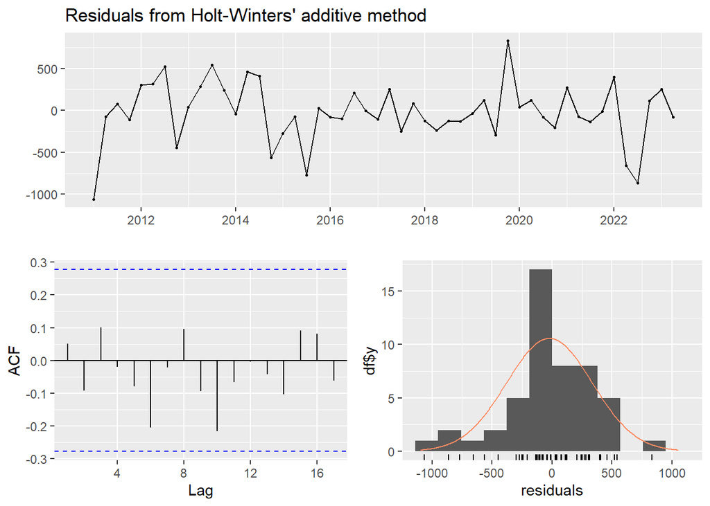

```
##
##  Ljung-Box test
##
## data:  Residuals from Holt-Winters' additive method
## Q* = 4.6106, df = 8, p-value = 0.7983
##
## Model df: 0.   Total lags used: 8
```

```r
checkresiduals(fit_hw_add)
```

Modeli Holt–Winters Additiv jep përshtatjen më të mirë për serinë e lindjeve. Ai kap trendin në rënie dhe sezonalitetin tremujor. Parashikimet janë afër vlerave reale të testit, ndërsa mbetjet janë të rastësishme (p-value 0.79), çka tregon se modeli është i specifikuar mirë.

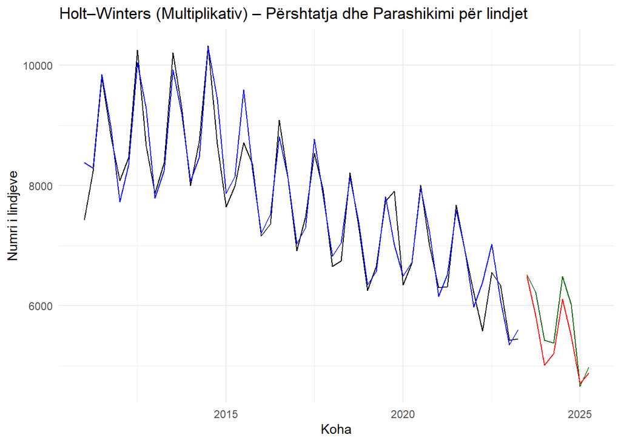

```r
fit_hw_mul <- hw(ts_train, h = h_test, seasonal = "multiplicative")

# Grafik: Train (real), Fitted, Test (real), Forecast
autoplot(ts_train, series = "Train", color = "black") +
  autolayer(fitted(fit_hw_mul), series = "Përshtatja (Fitted)", color = "blue") +
  autolayer(ts_test, series = "Reale (Test)", color = "darkgreen") +
  autolayer(fit_hw_mul$mean, series = "Parashikimi (HW Multiplikativ)", color = "red") +
  labs(title = "Holt–Winters (Multiplikativ) – Përshtatja dhe Parashikimi për lindjet",
       x = "Koha",
       y = "Numri i lindjeve") +
  guides(colour = guide_legend(title = "Seria")) +
  theme_minimal()
```

```r
# Saktësia dhe diagnostika (Multiplikativ)
acc_hw_mul <- accuracy(fit_hw_mul, ts_test)
acc_hw_mul
```

```
##                     ME     RMSE      MAE        MPE     MAPE      MASE
## Training set -61.70969 330.5513 226.1272 -0.9299323 3.011819 0.5573217
## Test set     245.44221 314.2722 256.5331  4.1476986 4.385599 0.6322612
##                     ACF1 Theil's U
## Training set -0.04923861        NA
## Test set     -0.10781498 0.4177405
```

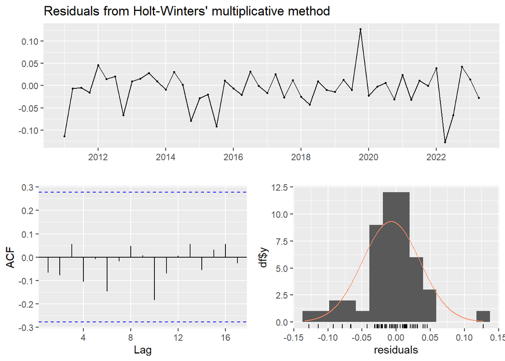

```
##
##  Ljung-Box test
##
## data:  Residuals from Holt-Winters' multiplicative method
## Q* = 2.8099, df = 8, p-value = 0.9457
##
## Model df: 0.   Total lags used: 8
```

```r
checkresiduals(fit_hw_mul)
```

Modeli multiplikativ pasqyron më saktë sezonalitetin e amplitudës së ndryshueshme,ka gabime më të ulëta krahasuar me Holt-in klasik dhe SES, sidomos në periudhën e testimit gjithashtu tregon parashikim të qëndrueshëm dhe të saktë, me devijim relativ shumë të vogël nga vlerat reale dhe mbetjet janë të rastësishme dhe pa strukturë.

## Krahasimi i saktësisë së modeleve

```r
library(dplyr)
library(tibble)

# Tabela e saktësisë për të gjithë modelet
acc_table <- bind_rows(
  data.frame(Model = "SES",               accuracy(fit_ses, ts_test)),
  data.frame(Model = "Holt",              accuracy(fit_holt, ts_test)),
  data.frame(Model = "HW Additive",       accuracy(fit_hw_add, ts_test)),
  data.frame(Model = "HW Multiplicative", accuracy(fit_hw_mul, ts_test))
)

# Përzgjedhja e metrikeve më të rëndësishme dhe renditja sipas RMSE
acc_table <- acc_table %>%
  select(Model, RMSE, MAE, MAPE, MASE) %>%
  arrange(RMSE)

knitr::kable(acc_table,
             caption = "Krahasimi i performancës së modeleve të parashikimit për serinë e lindjeve")
```

Krahasimi i performancës së modeleve të parashikimit për serinë e lindjeve

|  | Model | RMSE | MAE | MAPE | MASE |
| --- | --- | --- | --- | --- | --- |
| Test set…1 | HW Additive | 244.8182 | 202.4007 | 3.465276 | 0.4988444 |
| Test set…2 | HW Multiplicative | 314.2722 | 256.5331 | 4.385599 | 0.6322612 |
| Training set…3 | HW Multiplicative | 330.5513 | 226.1272 | 3.011819 | 0.5573217 |
| Training set…4 | HW Additive | 355.0670 | 258.4174 | 3.374753 | 0.6369052 |
| Test set…5 | Holt | 602.5093 | 543.2036 | 10.052108 | 1.3388002 |
| Test set…6 | SES | 730.2626 | 603.2135 | 11.452682 | 1.4867028 |
| Training set…7 | Holt | 819.3115 | 660.8020 | 8.570681 | 1.6286375 |
| Training set…8 | SES | 868.9258 | 722.3179 | 9.630332 | 1.7802519 |

Të dhënat tregojnë se Holt–Winters Additiv është modeli më i saktë, me RMSE dhe MAE më të ulët se modelet e tjera. HW Multiplikativ performon mirë, por më dobët se versioni additiv. Modelet SES dhe Holt tregojnë gabime të larta dhe nuk arrijnë të kapin strukturen sezonale të serisë.

### Modeli më i mirë dhe parashikimi 2 vjecar

```r
best_model <- acc_table$Model[1]
best_model
```

```
## [1] "HW Additive"
```

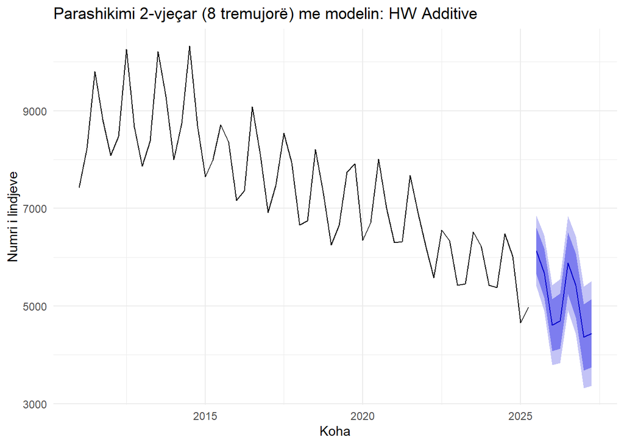

```r
final_fit <- switch(best_model,
                    "SES" = ses(ts_births, h = 8),
                    "Holt" = holt(ts_births, h = 8, damped = FALSE),
                    "HW Additive" = hw(ts_births, h = 8, seasonal = "additive"),
                    "HW Multiplicative" = hw(ts_births, h = 8, seasonal = "multiplicative"),
                    "ETS" = forecast(ets(ts_births), h = 8)
)

autoplot(final_fit) +
  ggtitle(paste0("Parashikimi 2-vjeçar (8 tremujorë) me modelin: ", best_model)) +
  xlab("Koha") +
  ylab("Numri i lindjeve") +
  theme_minimal()
```

Grafiku i parashikimit 2-vjeçar me modelin Holt-Winters Additiv tregon që trendi rënës i lindjeve pritet të vazhdojë. Zona blu shfaq intervalet e besimit (80% dhe 95%), të cilat rriten me kohën, duke reflektuar pasigurinë natyrore të parashikimeve afatgjata. Modeli kap mirë sezonalitetin dhe jep një projeksion realist për tremujorët e ardhshëm.

### Rezultatet e parashikimit

```r
library(lubridate)
library(tibble)

t <- time(final_fit$mean)

Viti <- floor(t)
Tremujori <- round((t - Viti) * 4 + 1)


Periudha <- paste0(Viti, "-Q", Tremujori)


final_fc_tbl <- tibble(
  Periudha = Periudha,
  Parashikim = as.numeric(final_fit$mean),
  Lwr95 = as.numeric(final_fit$lower[, "95%"]),
  Upr95 = as.numeric(final_fit$upper[, "95%"])
)

knitr::kable(final_fc_tbl, caption = "Parashikimi 2-vjeçar (8 tremujorë) me intervalet 95%")
```

Parashikimi 2-vjeçar (8 tremujorë) me intervalet 95%

| Periudha | Parashikim | Lwr95 | Upr95 |
| --- | --- | --- | --- |
| 2025-Q3 | 6129.718 | 5409.724 | 6849.711 |
| 2025-Q4 | 5669.537 | 4899.959 | 6439.115 |
| 2026-Q1 | 4610.412 | 3794.231 | 5426.592 |
| 2026-Q2 | 4693.026 | 3832.742 | 5553.311 |
| 2026-Q3 | 5879.643 | 4917.324 | 6841.961 |
| 2026-Q4 | 5419.462 | 4419.425 | 6419.499 |
| 2027-Q1 | 4360.337 | 3323.934 | 5396.739 |
| 2027-Q2 | 4442.952 | 3371.398 | 5514.505 |

Ky kod gjeneron një tabelë të strukturuar të parashikimit 2-vjeçar, ku secila vlerë e parashikuar shoqërohet me periudhën përkatëse (vit–tremujor) dhe intervalet 95% të besueshmërisë. Tabela ofron informacion të plotë mbi pritshmëritë e modelit dhe pasiguritë e tij, duke e bërë interpretimin e parashikimeve më të qartë dhe më të kuptueshëm.

# Proceset MA dhe AR

## Procesi MA(1)

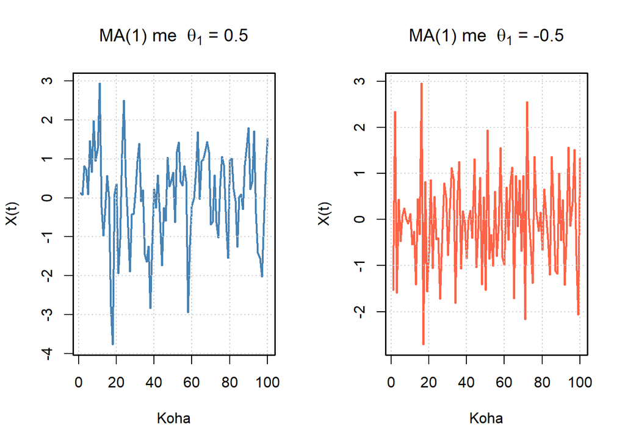

```r
library(forecast)

set.seed(42)
n <- 100

# Simulimet
ts_ma_pos <- arima.sim(model = list(ma = 0.5), n = n)
ts_ma_neg <- arima.sim(model = list(ma = -0.5), n = n)


par(mfrow = c(1, 2))

# Grafik 1: theta = 0.5
plot(ts_ma_pos,
     type = "l",
     col = "steelblue",
     lwd = 2,
     main = expression(paste("MA(1) me  ", theta[1], " = 0.5")),
     xlab = "Koha",
     ylab = "X(t)")
grid(col = "gray80")
box(lwd = 1.5)

# Grafik 2: theta = -0.5
plot(ts_ma_neg,
     type = "l",
     col = "tomato",
     lwd = 2,
     main = expression(paste("MA(1) me  ", theta[1], " = -0.5")),
     xlab = "Koha",
     ylab = "X(t)")
grid(col = "gray80")
box(lwd = 1.5)
```

```r
# Rikthen vendosjen e grafikëve në normale
par(mfrow = c(1,1))
```

Procesi MA(1) me θ₁ = 0.5 paraqet lëvizje më të buta për shkak të varësisë pozitive, ndërsa me θ₁ = –0.5 jep luhatje më të shpejta dhe seri më të paqëndrueshme për shkak të varësisë negative mes vlerave.

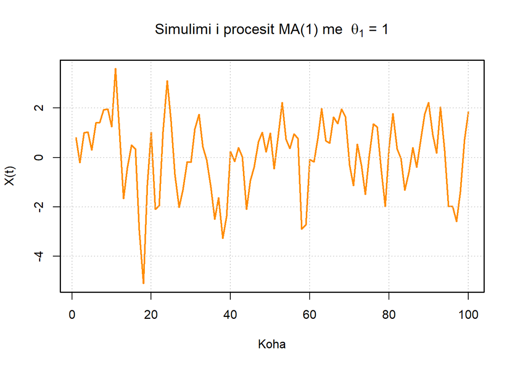

```r
# Simulimi i një procesi MA(1)
library(forecast)

set.seed(42)
n <- 100
ts_ma1_neg05 <- arima.sim(model = list(ma = 1), n = n)

# Grafik i përmirësuar
plot(ts_ma1_neg05,
     type = "l",
     col = "darkorange",
     lwd = 2,
     main = expression(paste("Simulimi i procesit MA(1) me  ", theta[1], " = 1")),
     xlab = "Koha",
     ylab = "X(t)")

grid(col = "gray80")
box(lwd = 1.5)
```

## ACF, ACVF, dhe PACF për Proceset MA(1)

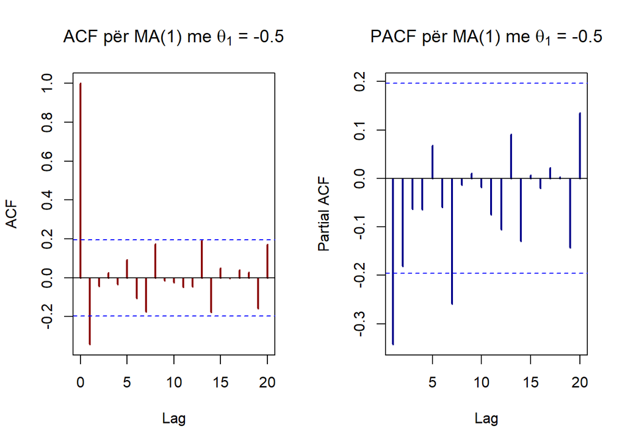

```r
# Simulimi i procesit MA(1) me theta = -0.5
set.seed(42)
ts_ma1_neg05 <- arima.sim(model = list(ma = -0.5), n = 100)

# ACF dhe PACF për procesin MA(1)
par(mfrow = c(1, 2))

acf(ts_ma1_neg05,
    main = expression(paste("ACF për MA(1) me ", theta[1], " = -0.5")),
    col = "darkred",
    lwd = 2)

pacf(ts_ma1_neg05,
     main = expression(paste("PACF për MA(1) me ", theta[1], " = -0.5")),
     col = "darkblue",
     lwd = 2)
```

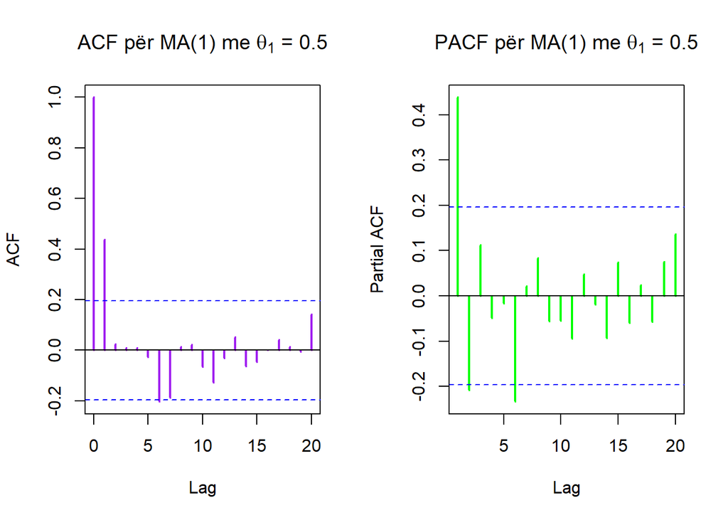

```r
# Simulimi i procesit MA(1) me theta = 0.5
set.seed(42)
ts_ma1_neg05 <- arima.sim(model = list(ma = 0.5), n = 100)

# ACF dhe PACF për procesin MA(1)
par(mfrow = c(1, 2))

acf(ts_ma1_neg05,
    main = expression(paste("ACF për MA(1) me ", theta[1], " = 0.5")),
    col = "purple",
    lwd = 2)

pacf(ts_ma1_neg05,
     main = expression(paste("PACF për MA(1) me ", theta[1], " = 0.5")),
     col = "green",
     lwd = 2)
```

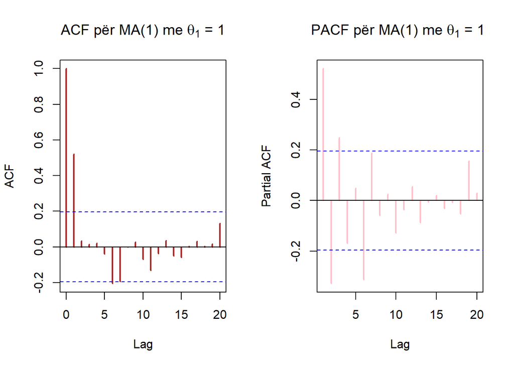

```r
# Simulimi i procesit MA(1) me theta = -1
set.seed(42)
ts_ma1_neg05 <- arima.sim(model = list(ma = 1), n = 100)

# ACF dhe PACF për procesin MA(1)
par(mfrow = c(1, 2))

acf(ts_ma1_neg05,
    main = expression(paste("ACF për MA(1) me ", theta[1], " = 1")),
    col = "brown",
    lwd = 2)

pacf(ts_ma1_neg05,
     main = expression(paste("PACF për MA(1) me ", theta[1], " = 1 ")),
     col = "pink",
     lwd = 2)
```

## MA(2)

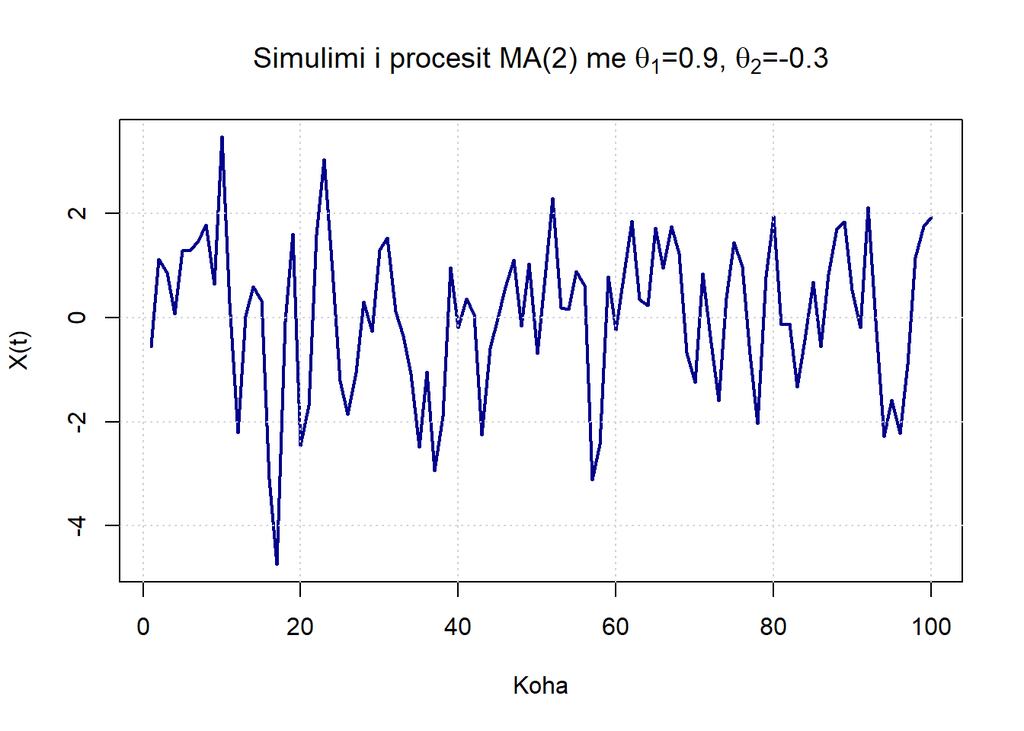

```r
# Koeficientët arbitrarë: theta1 = 0.9, theta2 = -0.3
set.seed(42)
ts_ma2 <- arima.sim(model = list(ma = c(0.9, -0.3)), n = n)

plot(ts_ma2,
     type = "l",
     col = "darkblue",
     lwd = 2,
     main = expression(paste("Simulimi i procesit MA(2) me ",
                             theta[1], "=0.9, ", theta[2], "=-0.3")),
     ylab = "X(t)",
     xlab = "Koha")

grid(col = "lightgray")
```

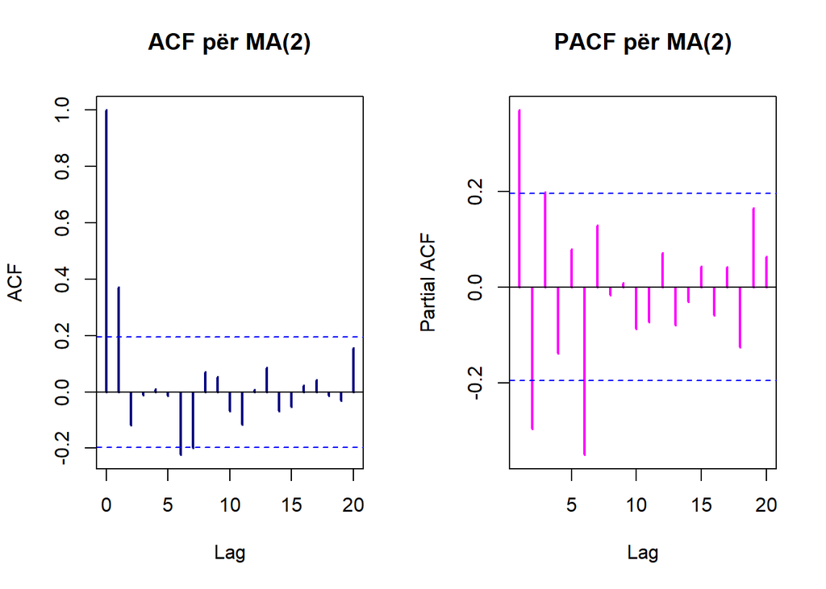

```r
par(mfrow = c(1, 2))

acf(ts_ma2,
    main = "ACF për MA(2)",
    col = "navy",
    lwd = 2)

pacf(ts_ma2,
     main = "PACF për MA(2)",
     col = "magenta",
     lwd = 2)
```

## MA(3)

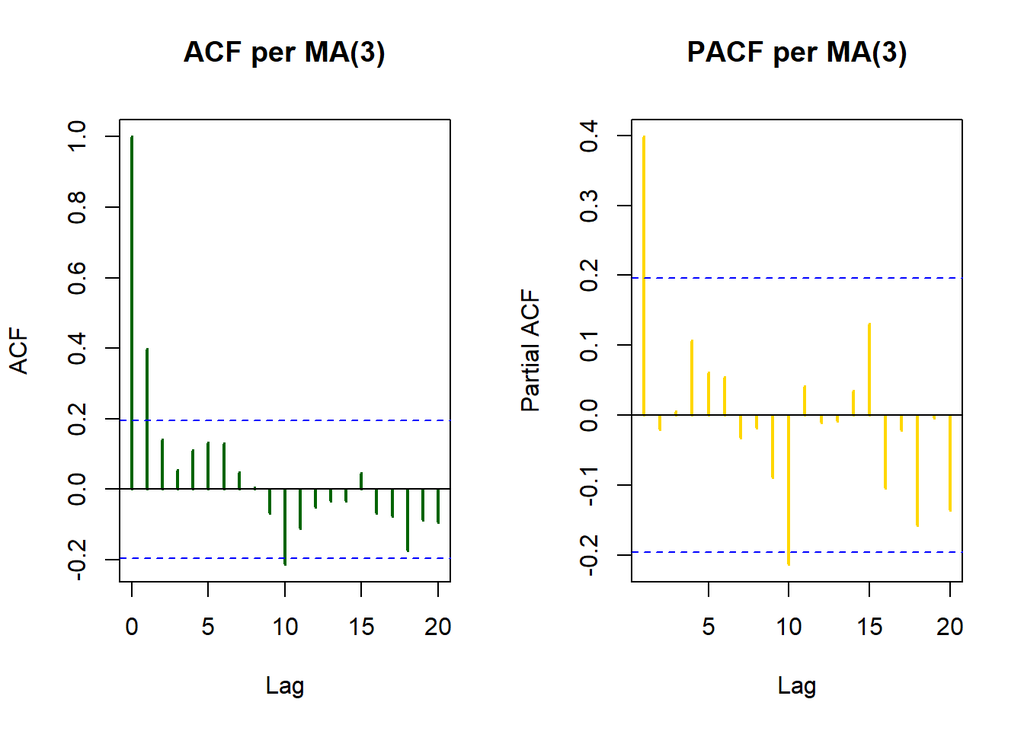

```r
# Koeficientët arbitrarë: thet1=0.5, thet2=0.3, thet3=0.2
ts_ma3 <- arima.sim(model = list(ma = c(0.5, 0.3, 0.2)), n = n)

par(mfrow = c(1, 2))
acf(ts_ma3,
    main = "ACF per MA(3)",
    col="darkgreen",
    lwd=2)
pacf(ts_ma3,
     main = "PACF per MA(3)",
     col="gold",
     lwd=2)
```

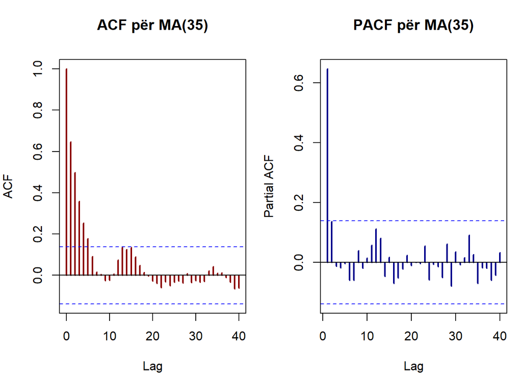

```r
# SIMULIMI I PROCESIT MA(35)

set.seed(42)
n <- 200

# Krijojmë 35 koeficientë MA
ma_params_35 <- c(
  0.6, 0.5, 0.4, 0.3, 0.25, 0.2, 0.15, 0.1,
  rep(0.05, 10),
  rep(0.02, 10),
  rep(0, 7)  # pjesa tjetër zero që plotëson 35 koeficientë
)

# Simulimi
ts_ma35 <- arima.sim(model = list(ma = ma_params_35), n = n)


par(mfrow = c(1, 2), mar = c(4, 4, 4, 1))

acf(ts_ma35,
    main = "ACF për MA(35)",
    lag.max = 40,
    col = "darkred",
    lwd = 2)

pacf(ts_ma35,
     main = "PACF për MA(35)",
     lag.max = 40,
     col = "darkblue",
     lwd = 2)
```

Si shembull bëjmë dhe MA(35)

## AR(2)

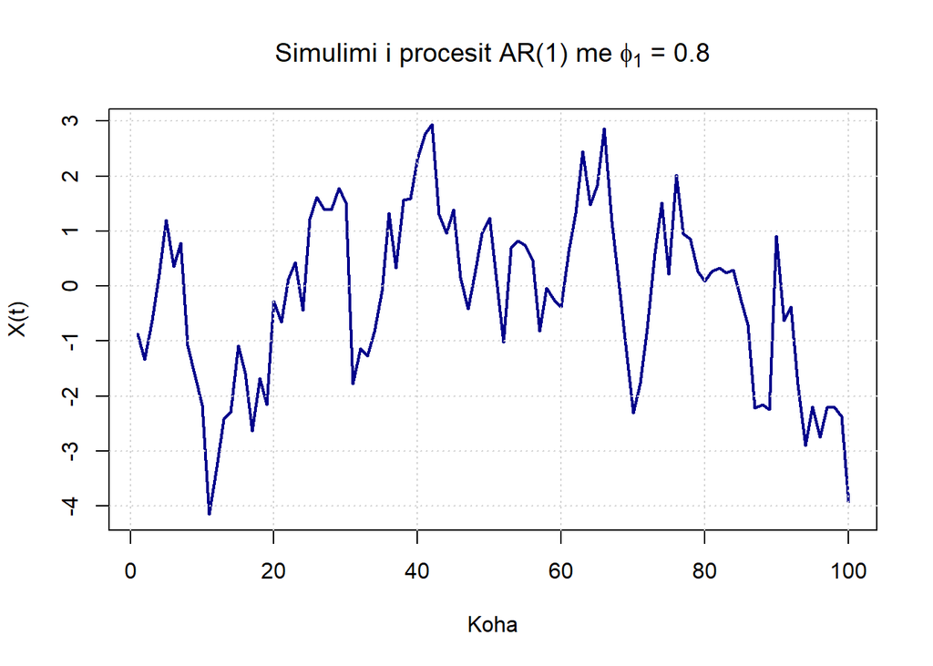

```r
# Simulimi i procesit AR(1) me phi = 0.8
set.seed(42)
n_sim <- 100

ts_ar1_pos08 <- arima.sim(model = list(ar = 0.8), n = n_sim)

plot(ts_ar1_pos08,
     type = "l",
     col = "darkblue",
     lwd = 2,
     main = expression(paste("Simulimi i procesit AR(1) me ", phi[1], " = 0.8")),
     ylab = "X(t)",
     xlab = "Koha")

grid(col = "lightgray")
```

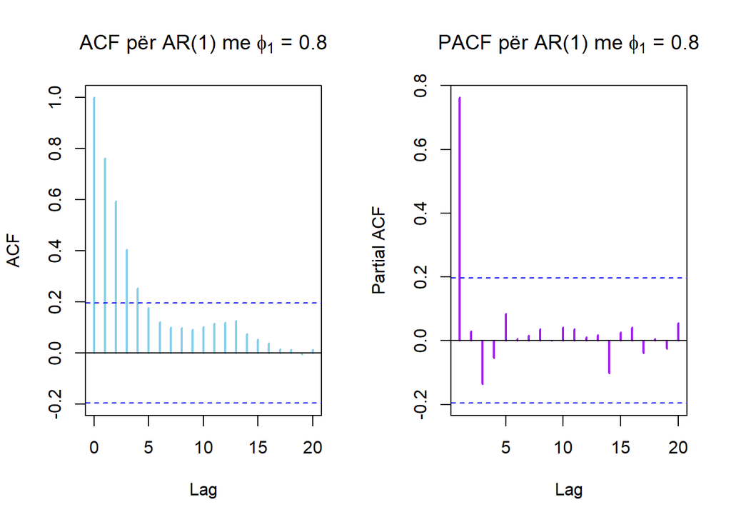

```r
par(mfrow = c(1, 2))

acf(ts_ar1_pos08,
    main = expression(paste("ACF për AR(1) me ", phi[1], " = 0.8")),
    col = "skyblue",
    lwd = 2)

pacf(ts_ar1_pos08,
     main = expression(paste("PACF për AR(1) me ", phi[1], " = 0.8")),
     col = "purple",
     lwd = 2)
```

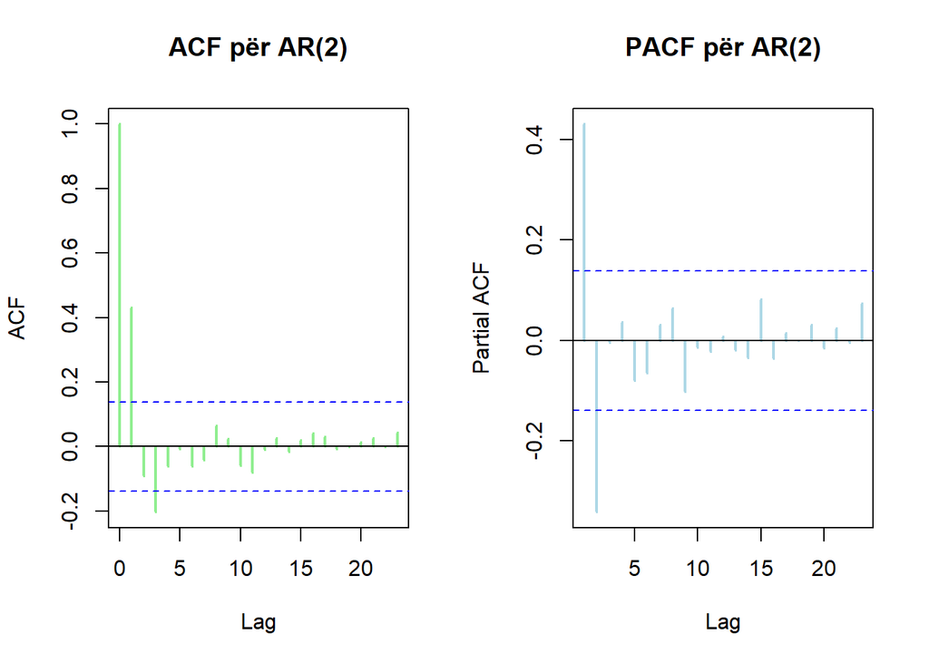

```r
# Simulimi i procesit AR(2)
set.seed(42)
ts_ar2 <- arima.sim(model = list(ar = c(0.6, -0.3)), n = n)

par(mfrow = c(1, 2))

acf(ts_ar2,
    main = "ACF për AR(2)",
    col = "lightgreen",
    lwd = 2)

pacf(ts_ar2,
     main = "PACF për AR(2)",
     col = "lightblue",
     lwd = 2)
```

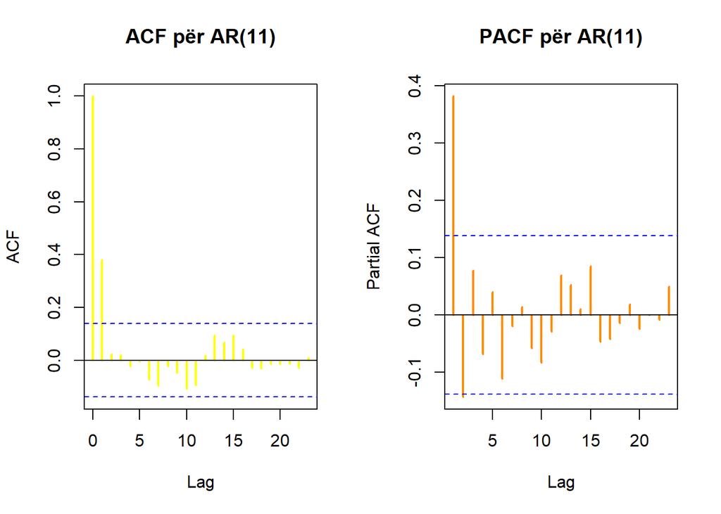

```r
# Simulimi i procesit AR(11)
set.seed(42)

phi_ar11 <- c(0.5, -0.2, 0.15, -0.1, 0.08, -0.06, 0.05, -0.04, 0.03, -0.02, 0.01)

ts_ar11 <- arima.sim(model = list(ar = phi_ar11), n = n)

par(mfrow = c(1, 2))

acf(ts_ar11,
    main = "ACF për AR(11)",
    col = "yellow",
    lwd = 2)

pacf(ts_ar11,
     main = "PACF për AR(11)",
     col = "darkorange",
     lwd = 2)
```

Si shembull kemi bërë dhe AR(11)